# AI Replication Games (Goldenberg et al., 2023) - Team 2

Rémi Thériault, Gaoyang Huang, & Vladimir Skavysh

Wed Apr 30 16:34:24 2025

This is a replication of Goldenberg et al. (2023) for the AI Replication Games (2025):

> Goldenberg, A., Abruzzo, J. M., Huang, Z., Schöne, J., Bailey, D., Willer, R., … & Gross, J. J. (2023). Homophily and acrophily as drivers of political segregation. *Nature Human Behaviour*, *7*(2), 219-230. https://doi.org/10.1038/s41562-022-01474-9

Replication package: https://osf.io/3g958/files/e0b4e0e1-31e6-4878-8b01-4d9531fdd9ee

Here are the goals:

1. First, computationally reproduce Figure 5.
2. Second, detect coding errors/data irregularities.
3. Last, propose and try to implement two robustness tests.

# Computationally reproducing Figure 5

```r
setwd("../Study_4_files")

suppressPackageStartupMessages(library(tidyverse))
suppressPackageStartupMessages(library (lme4))
library(see)
library(visdat)
library(performance)
library(bestNormalize)
library(report)
library(rempsyc)
```

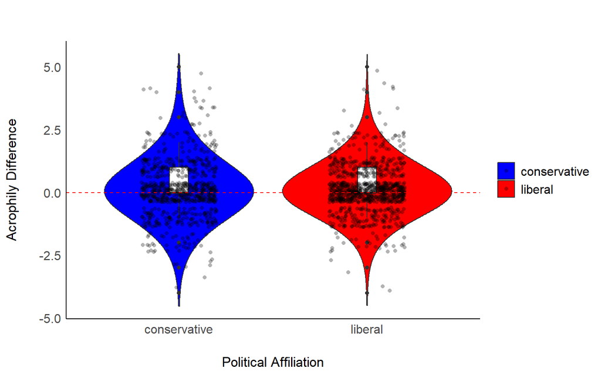

```r
d <- read_csv("study_4_data_osf.csv", show_col_types = FALSE)

# d$poli3 <- factor(d$poli3)

make_figure_5 <- function(data, x, y, seed = 42) {
  set.seed(42)
  ggplot(data, aes(x = .data[[x]], y = .data[[y]], fill = .data[[x]])) +
    geom_violin(trim = FALSE, adjust = 5) +
    geom_boxplot(width = 0.1, fill = "white") +
    geom_jitter(shape = 16, position = position_jitter(0.2), alpha = 0.3) +
    scale_fill_manual(values = c("Blue", "red")) +
    guides(fill = guide_legend(title = NULL)) +
    theme_bw() +
    theme(
      plot.title = element_text(hjust = 0.5, size = rel(1.5)),
      axis.title.y = element_text(face = "bold", size = 14),
      axis.text.x = element_text(angle = 45, vjust = 0.5, size = 10),
      axis.text.y = element_text(vjust = 0.5, size = 6),
      axis.title.x = element_text(vjust = 0.5, size = 10)
    ) +
    geom_hline(yintercept = c(0), linetype = "dashed", color = "red") +
    labs(
      title = "",
      x = "Political Affiliation",
      y = "Acrophily Difference"
    ) +
    theme_modern()
}

make_figure_5(d, "poli3", "acrophilyDif")
```

```r
ggsave("Figure 5.pdf", width = 8, height = 5)
ggsave("Figure 5.png", width = 8, height = 5)
```

# Detecting coding errors

All coding errors and data irregularities are reported in the Template Time Stamp spreadsheet available at: https://docs.google.com/spreadsheets/d/1AgmgmON3_fenenlaJ0LiX_DCgLHT1iOr/edit?usp=sharing&ouid=102400366711719963705&rtpof=true&sd=true.

# Robustness tests

We report below our two selected robustness checks:

## Robustness check 1: Duplicates

Let’s look into duplicates.

```r
d <- d %>%
  mutate(id_trial = paste0(participant_id, "_", trial), .before = participant_id)

duplicates <- rempsyc::extract_duplicates(d, id = "id_trial") %>%
  arrange(Row)

nrow(duplicates) / 2
```

```
## [1] 193
```

```r
duplicates %>%
  distinct(id_trial) %>%
  nrow()
```

```
## [1] 192
```

```r
# 192 duplicate observations (combinations of participant ID and trial), for
# a total of 386 participant_trial combination with duplication.

count(duplicates, id_trial, sort = TRUE) %>%
  head()
```

```
##   id_trial n
## 1    113_1 3
## 2    115_4 3
## 3     10_1 2
## 4     10_2 2
## 5    110_1 2
## 6    110_2 2
```

```r
d_no_duplicates <- rempsyc::best_duplicate(d, id = "id_trial")
```

```
## (194 duplicates removed)
```

```r
# (194 duplicates removed actually)

mean(d_no_duplicates$acrophilyDif)
```

```
## [1] 0.1254851
```

```r
mean(d$acrophilyDif)
```

```
## [1] 0.1241379
```

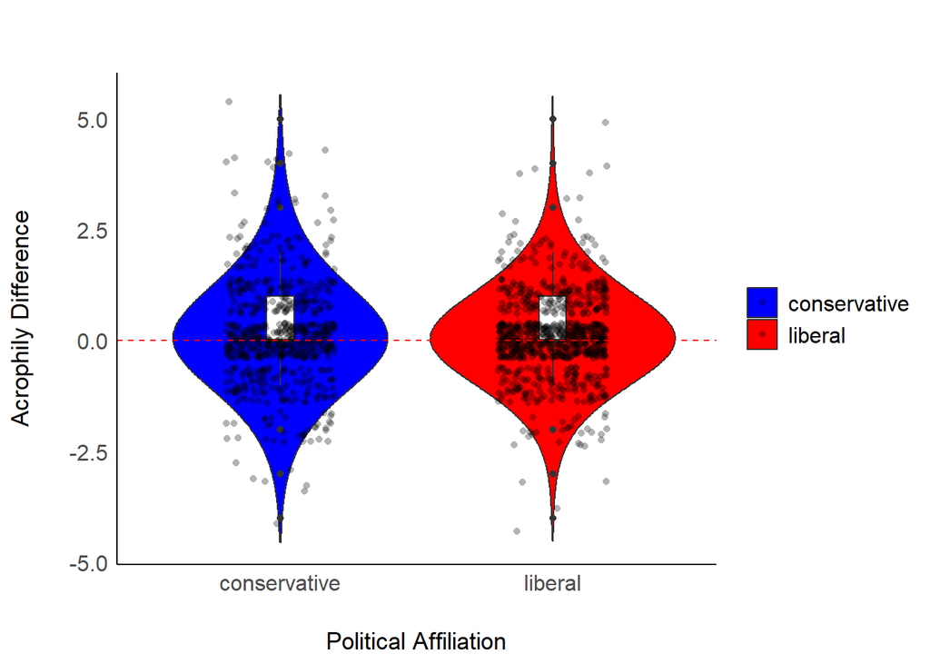

```r
make_figure_5(d_no_duplicates, "poli3", "acrophilyDif")
```

```r
ggsave("Figure 5_no_duplicates.pdf", width = 8, height = 5)
ggsave("Figure 5_no_duplicates.png", width = 8, height = 5)
```

The results are not so different.

## Robustness check 2: Absolute differences

Here, we check group differences (*t* tests) between Liberal and Conservatives after taking the absolute value of `acrophilyDif`. Consequently, `acrophilyDifAbs` is significantly different between the two group.

```r
# take the absolute value of acrophilyDif
d$acrophilyAbs <- abs(d$acrophilyDif)
# check with the whole dataset d
# In case it is useful, the lmer model below
# r3 <- lmer(acrophilyAbs ~ poli3 + (1 | concept) + (1 | participant_id), d)
# summary(r3)

# check with the dataset without outliers
d_no_extreme = filter(d, subjectRating!=1 &subjectRating!=7)
d_no_extreme$acrophilyAbs <- abs(d_no_extreme$acrophilyDif)

# In case it is useful, the lmer model below
# r4 <- lmer(acrophilyAbs ~ poli3 + (1 | concept) + (1 | participant_id), d_no_extreme)
# summary(r4)

t.test(acrophilyAbs ~ poli3, d_no_extreme) %>%
  report::report_table(data = d_no_extreme) %>%
  summary() %>%
  rempsyc::nice_table(highlight = TRUE)
```

| Difference | CI | t | df | p | Alternative | d | 95% CI (d) | 95% CI |
| --- | --- | --- | --- | --- | --- | --- | --- | --- |
| 0.15 | 0.95 | 3.09 | 1,026.06 | .002** | two.sided | 0.18 | [0.07, 0.30] | [0.05, 0.24] |

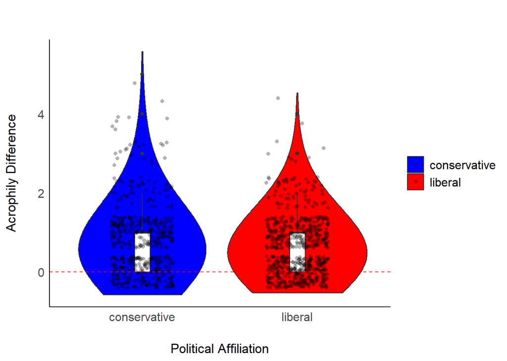

```r
make_figure_5(d_no_extreme, "poli3", "acrophilyAbs")
```

```r
t.test(acrophilyDif ~ poli3, d_no_extreme) %>%
  report::report_table(data = d_no_extreme) %>%
  summary() %>%
  rempsyc::nice_table()
```

| Difference | CI | t | df | p | Alternative | d | 95% CI (d) | 95% CI |
| --- | --- | --- | --- | --- | --- | --- | --- | --- |
| -0.01 | 0.95 | -0.17 | 1,015.01 | .869 | two.sided | -0.01 | [-0.12, 0.11] | [-0.13, 0.11] |

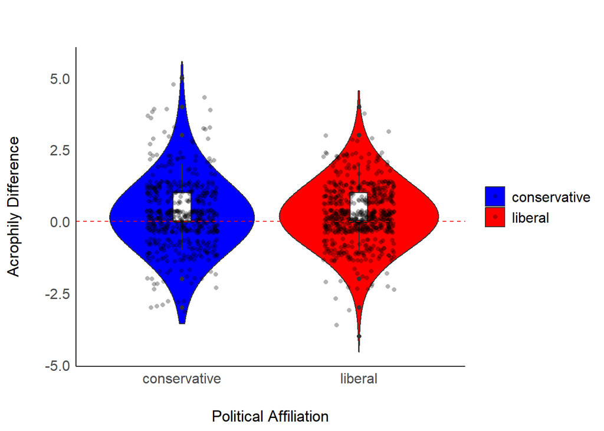

```r
make_figure_5(d_no_extreme, "poli3", "acrophilyDif")
```

## Other robustness checks

Let’s figure see if there are any missing data

```r
any(is.na(d))
```

```
## [1] TRUE
```

```r
rempsyc::nice_na(d)
```

```
## # A tibble: 1 × 8
##   var                  items    na cells na_percent na_max na_max_percent all_na
##   <chr>                <int> <int> <dbl>      <dbl>  <dbl>          <dbl>  <int>
## 1 id_trial:acrophilyA…    35   532 60900       0.87      1           2.86      0
```

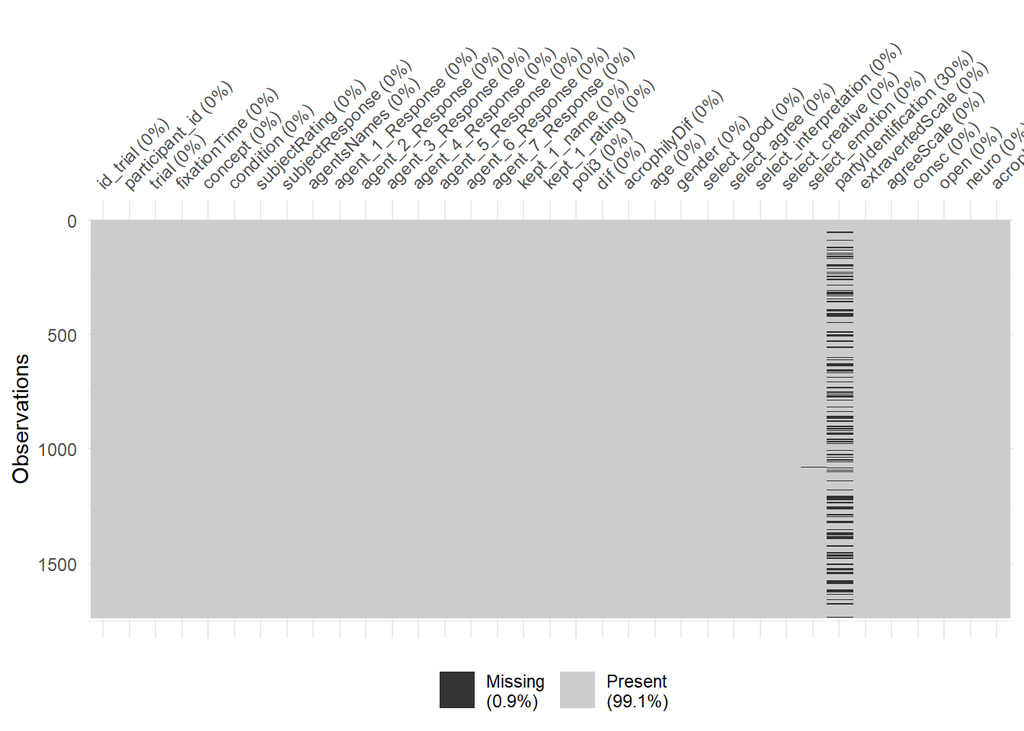

```r
vis_miss(d)
```

There is. Let’s see which columns contain missing data.

```r
names(d[as.logical(lapply(d, \(x) any(is.na(x))))])
```

```
## [1] "select_emotion"      "partyIdentification"
```

### Transformating data

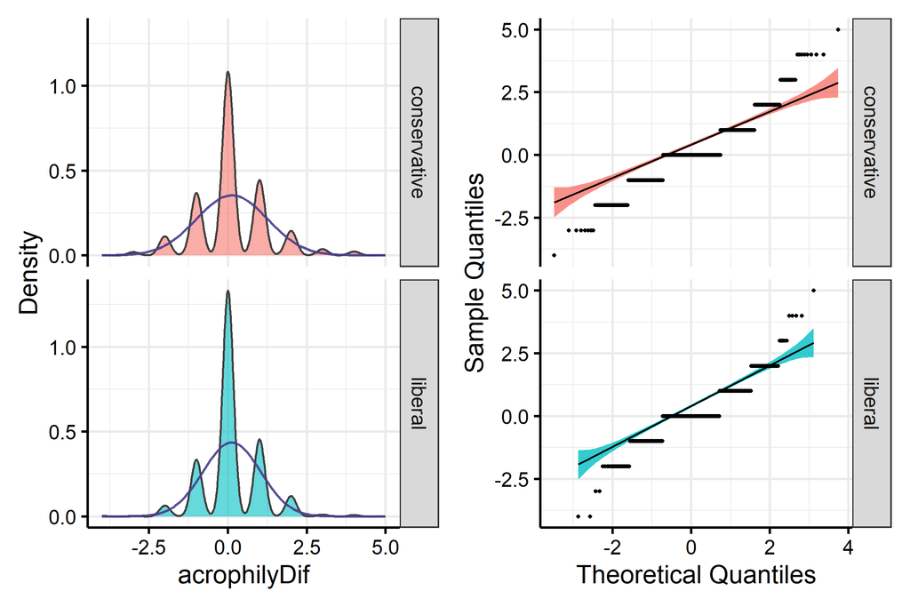

```r
rempsyc::nice_normality(d, "acrophilyDif", group = "poli3")
```

Results suggest that that the data are more or less normally distributed but not smooth, meaning there are peaks at certain values. This is because the scale is discrete:

```r
count(d, acrophilyDif, sort = TRUE)
```

```
## # A tibble: 10 × 2
##    acrophilyDif     n
##           <dbl> <int>
##  1            0   923
##  2            1   341
##  3           -1   266
##  4            2   100
##  5           -2    66
##  6            3    18
##  7            4    12
##  8           -3     9
##  9           -4     3
## 10            5     2
```

```r
count(d, poli3, sort = TRUE) %>%
  add_row(poli3 = "difference", n = 968-772)
```

```
## # A tibble: 3 × 2
##   poli3            n
##   <chr>        <dbl>
## 1 liberal        968
## 2 conservative   772
## 3 difference     196
```

That said, the distributions appear similar across liberals and conservatives, though there is 196 more liberals (11%) than conservatives.

We can still try to transform the data to normality using bestNormalize.

```r
predict_bestNormalize <- function(var) {
  x <- bestNormalize(var, standardize = FALSE, allow_orderNorm = FALSE)
  print(cur_column())
  print(x$chosen_transform)
  cat("\n")
  y <- predict(x)
  attr(y, "transform") <- c(attributes(y), attributes(x$chosen_transform)$class[1])
  y
}

transformation <- bestNormalize(d$acrophilyDif, standardize = FALSE, allow_orderNorm = FALSE)
transformation
```

```
## Best Normalizing transformation with 1740 Observations
##  Estimated Normality Statistics (Pearson P / df, lower => more normal):
##  - arcsinh(x): 62.6922
##  - Double Reversed Log_b(x+a): 62.5343
##  - Exp(x): 77.408
##  - Log_b(x+a): 62.3057
##  - No transform: 62.6356
##  - sqrt(x + a): 62.5295
##  - Yeo-Johnson: 62.6186
## Estimation method: Out-of-sample via CV with 10 folds and 5 repeats
##
## Based off these, bestNormalize chose:
## Non-Standardized Log_b(x + a) Transformation with 1740 nonmissing obs.:
##  Relevant statistics:
##  - a = 4.001
##  - b = 10
##  - mean (before standardization) = 0.5964371
##  - sd (before standardization) = 0.1872184
```

```r
d$acrophilyDif.t <- predict(transformation)
```

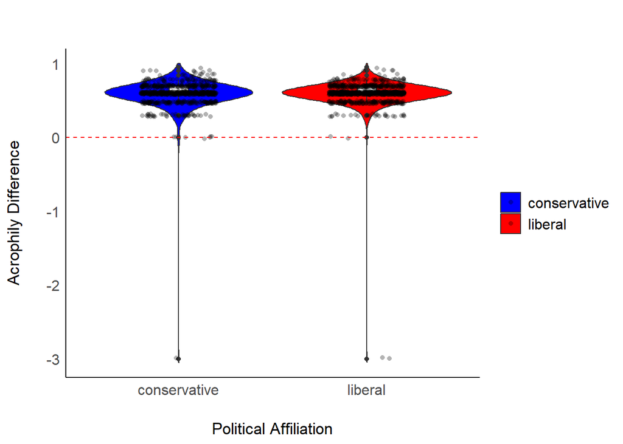

```r
make_figure_5(d, "poli3", "acrophilyDif.t")
```

```r
ggsave("Figure 5_normalized.pdf", width = 8, height = 5)
ggsave("Figure 5_normalized.png", width = 8, height = 5)
```

### Dealing with outliers

```r
outliers <- check_outliers(d[c("poli3", "acrophilyDif")])
outliers
```

```
## 17 outliers detected: cases 1, 61, 142, 305, 339, 540, 608, 669, 670,
##   833, 834, 1127, 1190, 1439, 1726, 1734, 1736.
## - Based on the following method and threshold: mahalanobis (10.828).
## - For variable: acrophilyDif.
```

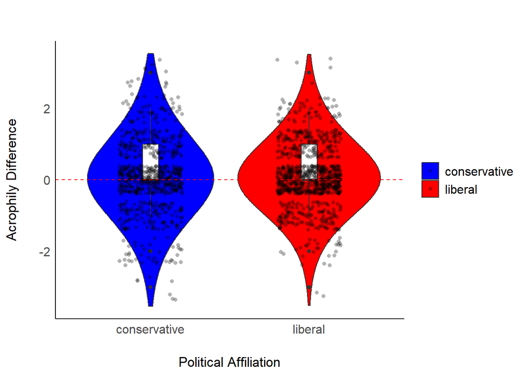

```r
outliers_list <- which(outliers)
d_outliers <- d[-outliers_list, ]

make_figure_5(d_outliers, "poli3", "acrophilyDif")
```

```r
ggsave("Figure 5_no outlier.pdf", width = 8, height = 5)
ggsave("Figure 5_no outlier.png", width = 8, height = 5)
```

### Splitting data by personality variables

For the second robustness check, we can check whether results depend on conscientiousness.

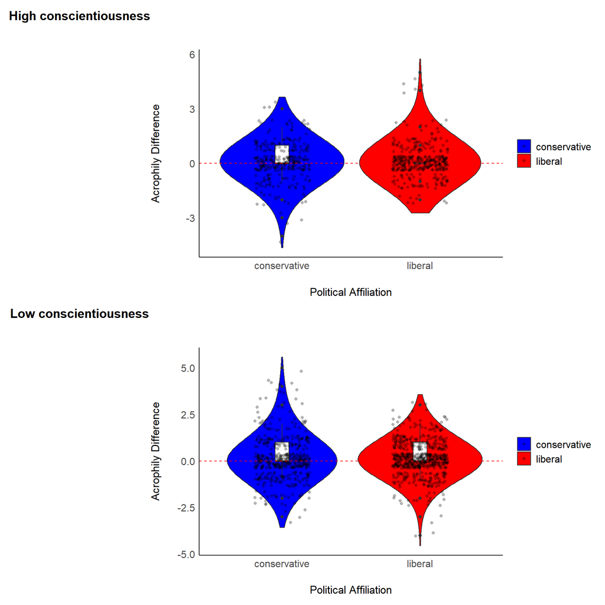

```r
d$consc_binary <- ifelse(d$consc > median(d$consc), 'high', 'low')

d_consc_high <- d %>%
  filter(consc_binary == "high")

d_consc_low <- d %>%
  filter(consc_binary == "low")

p_d_consc_high <- make_figure_5(d_consc_high, "poli3", "acrophilyDif")

p_d_consc_low <- make_figure_5(d_consc_low, "poli3", "acrophilyDif")

plots(p_d_consc_high, p_d_consc_low, n_rows = 2,
      tags = c("High conscientiousness", "Low conscientiousness"))
```

```r
ggsave("Figure 5_consc.pdf", width = 8, height = 8)
ggsave("Figure 5_consc.png", width = 8, height = 8)
```

Or party identification…

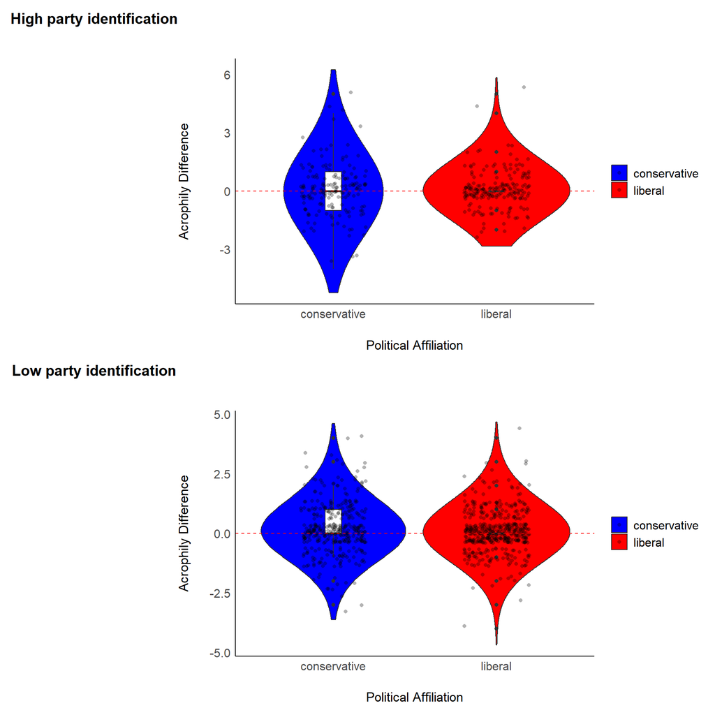

```r
d$partyIdentification_binary <- ifelse(d$partyIdentification > median(d$partyIdentification, na.rm = TRUE),
                                       'high', 'low')

d_partyIdentification_high <- d %>%
  filter(partyIdentification_binary == "high")

d_partyIdentification_low <- d %>%
  filter(partyIdentification_binary == "low")

p_d_partyIdentification_high <- make_figure_5(d_partyIdentification_high, "poli3", "acrophilyDif")

p_d_partyIdentification_low <- make_figure_5(d_partyIdentification_low, "poli3", "acrophilyDif")

plots(p_d_partyIdentification_high, p_d_partyIdentification_low, n_rows = 2,
      tags = c("High party identification", "Low party identification"))
```

```r
ggsave("Figure 5_partyIdentification.pdf", width = 8, height = 8)
ggsave("Figure 5_partyIdentification.png", width = 8, height = 8)
```